# Sensitivity testing: Yield bright spots

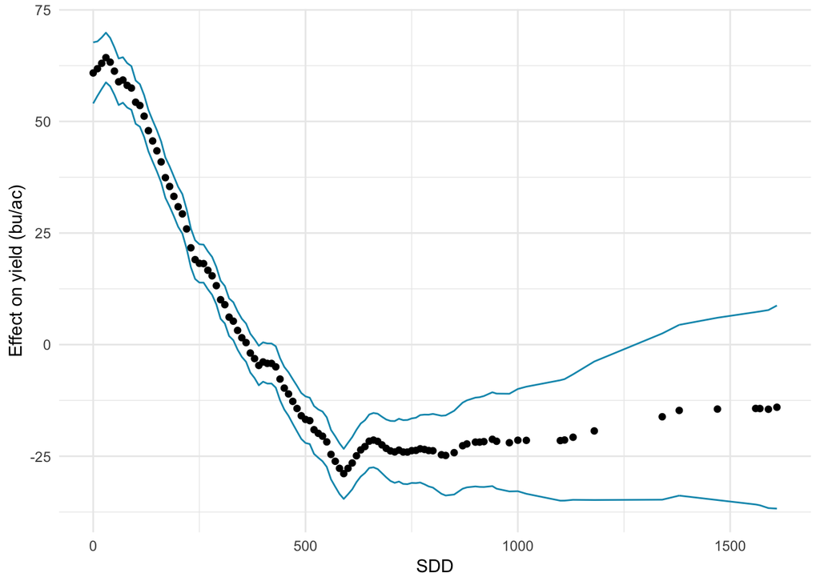

```r
sdd <- nonlinear_effect(o8, "SDD")
gdd <- nonlinear_effect(o8, "GDD")
tp <- nonlinear_effect(o8, "TP")
sdd
```

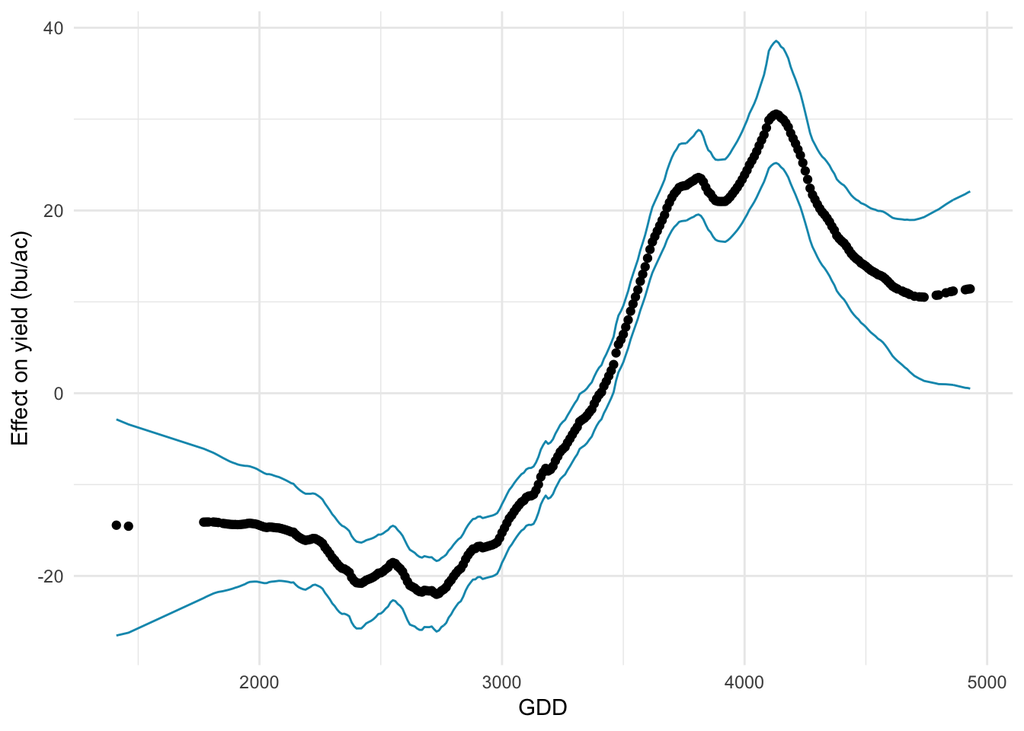

```r
gdd
```

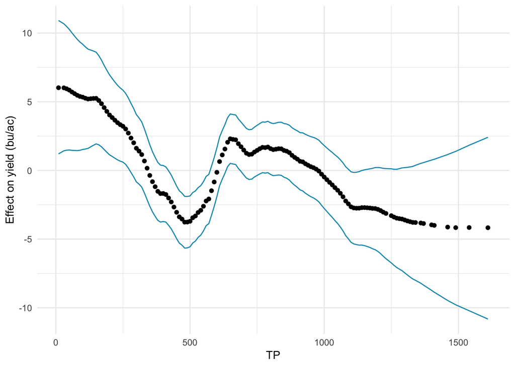

```r
tp
```

# 3. Final model description (2.7)

Formalization:

$$y_{ij} ~ N(\mu_{ij}, \sigma^2)$$
$$\mu_{ij} = \beta_{0j} + f(X_{cty}) + \beta_1 Z_{cty}$$
$$\beta_{0j} = b_0 + u_i + v_i$$

And $\beta_{0j}$ can be computed as:

```r
# code for computing B_{0j}
n <- length(unique(null$GEOID))
b0 <- inla.rmarginal(1000, marg = modr$marginals.fixed$`(Intercept)`)
v0 <- matrix(NA, 1000, n)
for (i in 1:n) {
  v0[,i] <- inla.rmarginal(1000, marg = modr$marginals.random$ID[[i]])
}

beta0 <- b0+v0
beta0_quartiles <- as.data.frame(t(apply(beta0, MARGIN=2, function(x) quantile(x, probs = c(0.025, 0.5, 0.975)))))
beta0_quartiles$ID <- unique(null$GEOID)
```

Prior information:

- The precision on the county-level random effects is defined using PC priors (see below)
- The $\phi$ value for the county-level spatial effects is also defined using PC priors.
- The state-level precision on the iid random effects is defined using informative logGamma priors based on the residual variation from a simple linear model.
- The precision for the non-parametric smoothing parameter is based on the recommendations on the `rw1` documentation.

The final model is a random-effects panel model that includes the following:

## 3.1. County-level random effects ($v_i$)

County random effects (deviation of the county mean, $v_i$ from the population mean, $b_0$). These effects account for any time-invariant factors that differ across counties. The precision of these effects is based on the penalized complexity prior specifications specified in [Simpson et al, 2016](https://arxiv.org/pdf/1403.4630.pdf) and listed in [this code.](http://inla.r-inla-download.org/r-inla.org/case-studies/pc-prior/bym/bym.R)

## 3.2. County-level spatial effects ($u_i$)

Intrinsic conditional autoregressive (iCAR) structured residuals at the county-level ($u_i$) were included to account for the fact that nearby things are similar (high spatial autocorrelation in the data).

This variance structure recognizes the fact that in the presence of strong spatial correlation, the more neighbors an area has the more information there is about the random effect, while the variance parameter (precision for ID, $\gamma_{u}^2$) controls the amount of variation between the spatially structured random effects. The parameter $\phi$ controls the “properness” of the distribution (p. 178). `bym` sets $\phi$ to 1, the `bym2` applies some flexibility here.

The precision on these effects is based on the standard error of the residuals from a linear regression, as done [here](http://www.maths.bath.ac.uk/~jjf23/inla/multiple.html#informative-gamma-priors-on-the-precisions) for a penalized complexity prior, so we scale the SDs of the random effects using the SD of the residuals of the fixed effects only model. Will need to review [this](https://arxiv.org/pdf/1403.4630v3.pdf) for full understanding of this parameterization.

Besag model where each region conditionally has a Gaussian distribution with mean equal to the average of the neighbors adn a precision proportional to the number of neighbors.

Besag along accounts for only similarities between regions, but doesn’t account for the fact that every region will have a bit of individual spice, adding an iid random effect in each region (a random intercept) helps - this is BYM.

$$\eta_i = \mu + u_i + v_i + f(c)$$

Where u is the structured/spatial component, and v is the unstructured component. $f(c)$ is the non-linear effect of covariate c and the precitions $\tau_u$, $\tau_v$, and a smoothing parameter $\tau_f$ - common to use indpendent gamma priors here.

This is a classic bym model - but the issue is that this is complicated, the split variance, split components, “it would be much easier to have one parameter controlling the scale of the ramdom effect and another controlling its makeup” - this is bym2. Rewrite the models as:

$$\eta = \frac{1}{\sqrt{\tau}} ( \sqrt(1 - \gamma)v + \sqrt{\gamma}u)$$

With marginal precisions $\tau$ and $\gamma$ gives it interpretation, insependence with value of zero, maximal dependence with value of 1. The PC prior on gamma depends on the graph! The previous has a covariance matrix:

$$Var(b|\tau_b, \phi) = \tau_{b}^{-1} ((1-\phi)I + \phi Q_{*}^-)$$

Using this new parameterization based on the scaled structured component $u_*$ where $Q_*$ is the precision matrix of the Besag model scaled according to 3.2 ([here](https://arxiv.org/pdf/1601.01180.pdf)). Now $Var(b|\tau_b, \phi)$ has a clear intretation. So $0 \leq \phi \leq 1$ measures the proportion of the marginal variance explained by the structured effect. Pure spatial dispersion with zero, only spatially structured values with 1.

PC priors allows us to distribute the total variance of the components of the BYM2 model - first, a prior for $\tau_b$ is defined which will contorl the marginal variance contribution of the weighted sum of v and u. Second, the marginal variance is distributed to the components v and u by defining a suitable parameter for the mixing parameter $phi$.

The second level base model is defined as having only unstructured spatial noise and no spatial dependency ($\phi=0$). By increasing this value, spatial dependency is gradually blended into the model and the model component explaining most of the varianec shifts from v to u.

## 3.3. State-level random effects

The `iid` state-level random effects are parameterized based on the residual variability from a simple linear model with all covariates in the null model.

## 3.4. Non-linear covariate effects $f(X)$

Non-parametric effects of seasonal temperature and precipitation using a first-order random walk function (`rw1`). The $\theta$ hyperparameter is parameterized as recommended for Gaussian models, where $u$ is the empirical standard deviation of the data and $\alpha$ is 0.01 (as described [here](https://inla.r-inla-download.org/r-inla.org/doc/latent/rw1.pdf)).

## 3.5. To develop:

- These models also employ sum-to-zero constraints for all random effects, see [this reference](https://link.springer.com/article/10.1007%2Fs00477-017-1405-0).
- Student T distribution
- hyperpar()

More notes to incorporate:

The hierarchical structure assumes an intercept for each state, where
$$B_{0j} = b_0 + v_{0j}$$
with
$$v_{0j} ~ Normal(0, \sigma_{v_0}^2)$$
. On the log precision a noninfomrative logGamme prior is assumed. The model basicall includes group-specific intercepts (random intercepts model) - there’s no real reason to think that the way in whcih climate affects yield of a particular crop varies across space, therefore, random slopes were not assessed. The idea is that we change our regression model to have group-specific intercepts… So start with
$$y_{ij} ~ N(\mu_{ij}, \sigma^2)$$
. Then break down the mean as follows (for random intercept, other exaplines on 151)…

$$\mu_{ij} = \beta_{0j} + \beta_i x_{ij} , \beta_{0j} = b_0 + v_{0j}$$

Where $b_1$ is a fixed effect, trypically normally distributed with mean of zero and a large variance. $v_{0j}$ is a random effect, typucally normally distributed with an exchangeable structure, i.e $v_{0j} ~ N(0, \sigma_{v_0}^2)$. Here we estimate a random intercept model. This is like saying the regression lines are parallel (effects are the same) but the intercept varies.

The hierarchical model shrinks the balues of $B_{0j}$ toward their mean since they are all generated by a distribution characterized by the same precision. This means that they are similar wihich has an impact in reducing the uncertainty in the estimates, as they can borrow strength from each other. Known as global smoothing.